# Homework 2

Diana Rueda

10/18/2020

### Question 1

1. Simulate a series of 𝑛=500 Gaussian white noise observations as in Example 1.7 of textbook and compute the smaple ACF, 𝜌̂(ℎ) to lag 20. Compare the sample ACF you obtained to the actual ACF, 𝜌(ℎ).
2. Repeat part (a) using only 𝑛=50. How does changing n affect the results?

autocovariance = {sigma^2 if h=0 and 0 if h != 0} From example 2.17

```r
library(astsa)
```

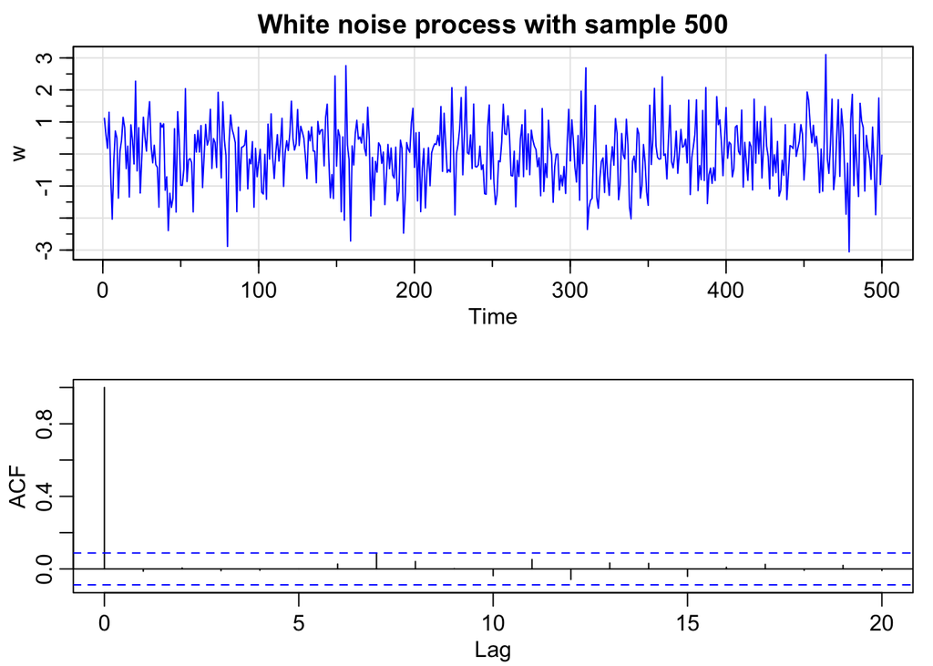

```r
# a
#simulate a series gaussian n=500
layout(matrix(1:2,2), widths = c(2.5,1))
w = rnorm(500,0,1)
tsplot(w, col = 4, main = "White noise process with sample 500")
#compute ACF to lag 20
acf(w,20)
```

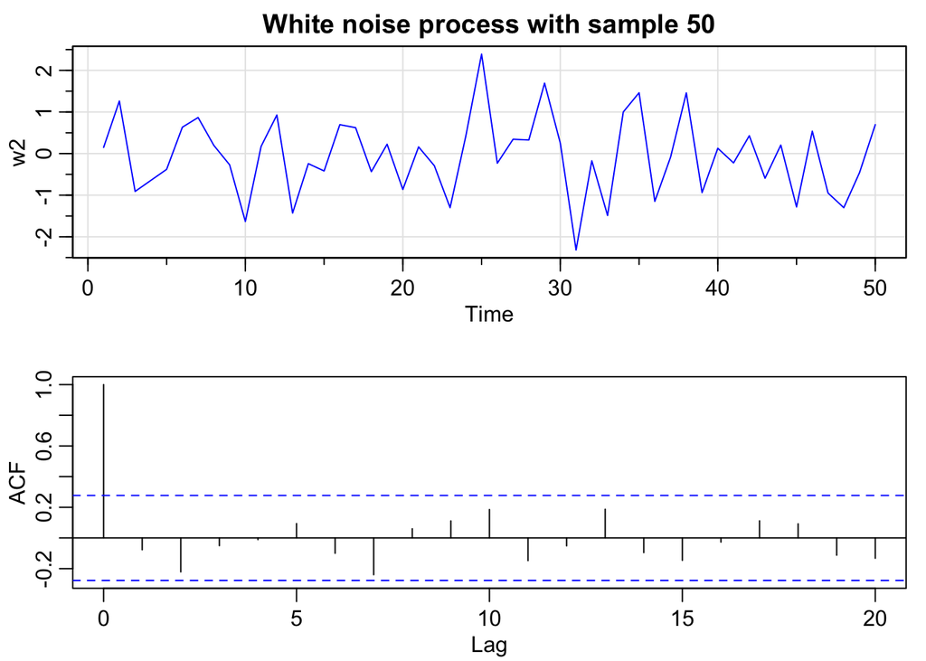

```r
# b
#simulate a series gaussian n=500
layout(matrix(1:2,2), widths = c(2.5,1))
w2 = rnorm(50,0,1)
tsplot(w2, col = 4, main = "White noise process with sample 50")
#compute ACF to lag 20
acf(w2,20)
```

From the information stated avobe we know that the actual value of this series’ population ACF equals 1 at h=0 and 0 at any other value of h. From the plots we observe that the sample ACF fluctuates around zero after h=1. The amount of fluctuation increases with n=50. Thus increasing n from 50 to 500 decreases the ACF for non-zero values of h. AS n increases the sample ACF gets closer to the actual ACF.

### Question 2.

1. Simulate a series of n=500 moving average observations as in Example 1.8 of textbook and compute the sample ACF, 𝜌̂(ℎ), to lag 20. Compare the sample ACF you obtained to the actual ACF, 𝜌(ℎ).
2. Repeat part (a) using only n=50. How does changing n affect the results.

autocovariance = {(3/9) sigma^2 for h=0, (2/9)sigma^2 for |h|=1, (1/9)sigma^2) for |h|=2, 0 for |h|>2} from example 2.18

and the ACF = {1 for h=0, (2/3) for |h|=1, (1/3) for |h|=2, 0 for |h|>2} from example 2.18

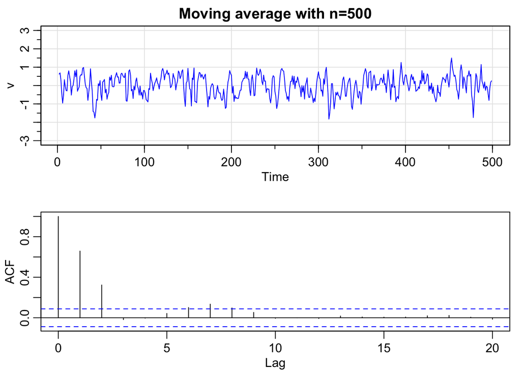

```r
# a
#simulate a moving average n=500
layout(matrix(1:2,2), widths = c(2.5,1))
v = filter(w, sides = 2, filter = rep(1/3, 3))
tsplot(v, ylim = c(-3,3), col = 4, main = "Moving average with n=500")
#compute ACF to lag 20
v = v[!is.na(v)]
acf(v, 20)
```

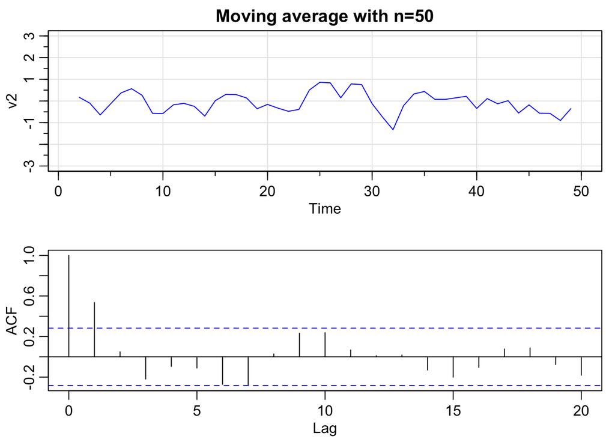

```r
# b
#simulate a moving average n=50
layout(matrix(1:2,2), widths = c(2.5,1))
v2 = filter(w2, sides = 2, filter = rep(1/3, 3))
tsplot(v2, ylim = c(-3,3), col = 4, main = "Moving average with n=50")
#compute ACF to lag 20
v2 = v2[!is.na(v2)]
acf(v2, 20)
```

If we compare the actual ACF to the ACF obtained from the series with sample size 500, we can see that the estimates for h=0,1,2 are very close to the actual values. However if we decrease the sample size to 50 only the ACF value for h=1 resembles the actual value. The ACF for |h|>1 is significantly less accurate.

### Question 3

For the Johnson & Johnson data, say 𝑌𝑡, shown in Figure 1.1 of textbook, let 𝑋𝑡=𝑙𝑜𝑔(𝑌𝑡). In this problem, we are going to fit a special type of structural model, 𝑋𝑡=𝑇𝑡+𝑆𝑡+𝑁𝑡 where 𝑇𝑡 is a trend component, 𝑆𝑡 is a seasonal component, and Nt is noise. In our case, time t is in quarters (1960.0,1960.25,…) so one unit of time is a year.

1. Fit the regression model

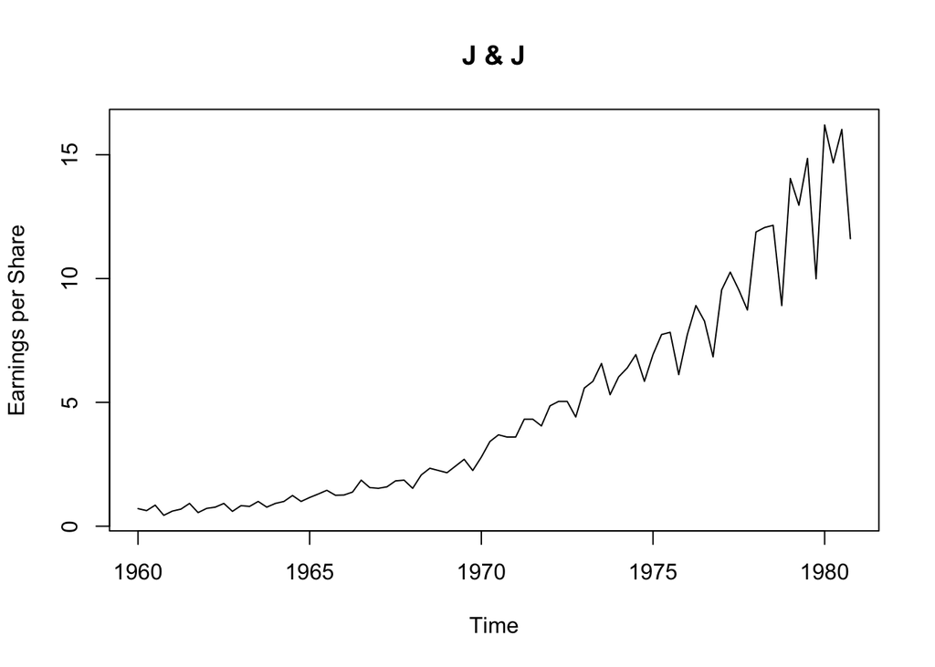

```r
#jj is a collection of 84 numbers called a time series
plot(jj, ylab="Earnings per Share", main="J & J")
```

```r
Q = factor(cycle(jj)) #make quarter factors
trend = time(jj) - 1970 #not necessary to center time -looks nicer
reg = lm(log(jj) ~  0 + trend + Q, na.action = NULL) #
summary(reg)
```

```
##
## Call:
## lm(formula = log(jj) ~ 0 + trend + Q, na.action = NULL)
##
## Residuals:
##      Min       1Q   Median       3Q      Max
## -0.29318 -0.09062 -0.01180  0.08460  0.27644
##
## Coefficients:
##       Estimate Std. Error t value Pr(>|t|)
## trend 0.167172   0.002259   74.00   <2e-16 ***
## Q1    1.052793   0.027359   38.48   <2e-16 ***
## Q2    1.080916   0.027365   39.50   <2e-16 ***
## Q3    1.151024   0.027383   42.03   <2e-16 ***
## Q4    0.882266   0.027412   32.19   <2e-16 ***
## ---
## Signif. codes:  0 '***' 0.001 '**' 0.01 '*' 0.05 '.' 0.1 ' ' 1
##
## Residual standard error: 0.1254 on 79 degrees of freedom
## Multiple R-squared:  0.9935, Adjusted R-squared:  0.9931
## F-statistic:  2407 on 5 and 79 DF,  p-value: < 2.2e-16
```

2. If the model is correct, what is the estimated average annual increase in the logged earnings per share?

3. If the model is correct, does the average logged earnings rate increase or decrease from the third quarter to the fourth quarter? And, by what percentage does it increase or decrease?

The rate decreases by 1.151024 - 0.882266 = 0.2687574. It decreased by (0.2687574/1.151024)x100 = 23.34941756 %.

4. What happens if you include an intercept term in the model in (a)? Explain why there was a problem.

```r
#add an intercept
reg_no_int = lm(log(jj) ~ trend + Q, na.action = NULL)
summary(reg_no_int)
```

```
##
## Call:
## lm(formula = log(jj) ~ trend + Q, na.action = NULL)
##
## Residuals:
##      Min       1Q   Median       3Q      Max
## -0.29318 -0.09062 -0.01180  0.08460  0.27644
##
## Coefficients:
##              Estimate Std. Error t value Pr(>|t|)
## (Intercept)  1.052793   0.027359  38.480  < 2e-16 ***
## trend        0.167172   0.002259  73.999  < 2e-16 ***
## Q2           0.028123   0.038696   0.727   0.4695
## Q3           0.098231   0.038708   2.538   0.0131 *
## Q4          -0.170527   0.038729  -4.403 3.31e-05 ***
## ---
## Signif. codes:  0 '***' 0.001 '**' 0.01 '*' 0.05 '.' 0.1 ' ' 1
##
## Residual standard error: 0.1254 on 79 degrees of freedom
## Multiple R-squared:  0.9859, Adjusted R-squared:  0.9852
## F-statistic:  1379 on 4 and 79 DF,  p-value: < 2.2e-16
```

When we include the intercept as done in the summary table above, the intercept takes on the weight of the first quarter, making the first quarter desapear, and affects all other seasonal terms by the amount of the first quarter. Thus this is a problem because we want to study each seasonal term separately.

5. Graph the data, 𝑋𝑡, and superimpose the fitted values, say 𝑋̂𝑡, on the graph. Examine the residuals, 𝑋𝑡−𝑋̂𝑡, and state your conclusions, Does it appear that the model fits the data well (do the residuals look white)?

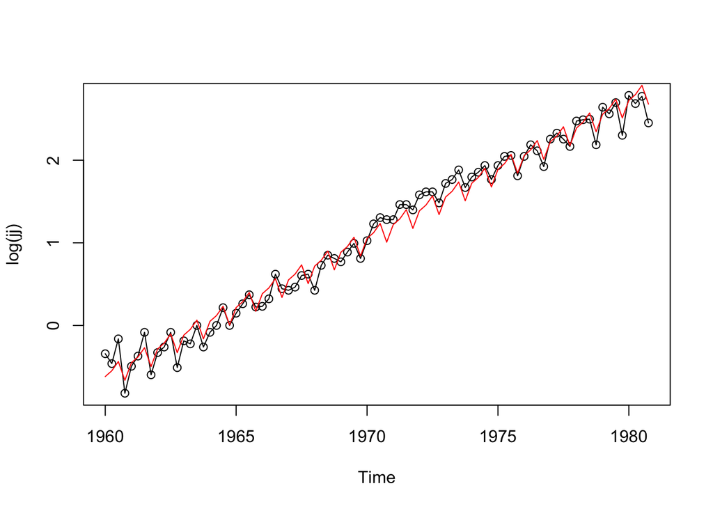

```r
#layout(matrix(1:3,3), widths = c(2.5,1))
plot(log(jj), type="o")    # the data in black with little dots
lines(fitted(reg), col=2)  # the fitted values in bloody red
```

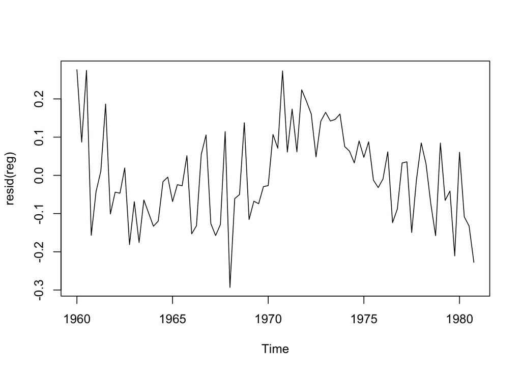

```r
#par(mfrow = c(2,1))
plot(resid(reg))       # residuals
```

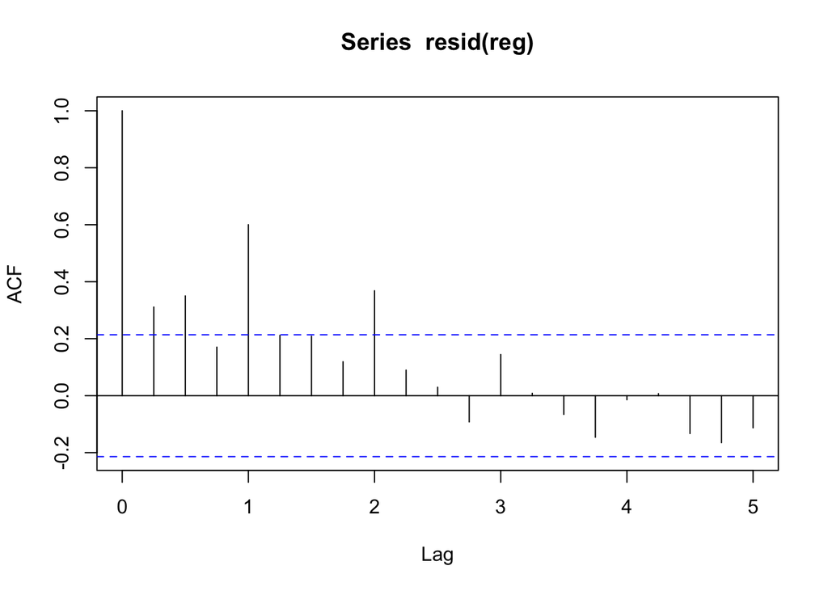

```r
acf(resid(reg), 20)    # acf of the resids
```

### Question 6

The glacial varve record plotted in Figure 3.9 exhibits some nonstationarity that can be improved by transforming to logarithms and some additional nonstationarity that can be corrected by differencing the logarithms.

1. Argue that the glacial varves series, say 𝑋𝑡, exhibits heteroscedasticity by computing the sample variance over the first half and the second half of the data. Argue that the transformation 𝑌𝑡=𝑙𝑜𝑔(𝑋𝑡) stabilizes the variance over the series. Plot the histograms of 𝑋𝑡 and 𝑌𝑡 to see whether the approximation to normality is improved by transforming the data.

```r
varve_firsthalf = varve[1:317]
varve_secondhalf = varve[318:634]
#compute sample variance on the first half of the data
var(varve_firsthalf)
```

```
## [1] 133.4574
```

```r
#compute sample variance on the second half of the data
var(varve_secondhalf)
```

```
## [1] 594.4904
```

```r
logvarve_firsthalf = log(varve[1:317])
logvarve_secondhalf = log(varve[318:634])
#compute sample variance on the first half of the data
var(logvarve_firsthalf)
```

```
## [1] 0.2707217
```

```r
#compute sample variance on the second half of the data
var(logvarve_secondhalf)
```

```
## [1] 0.451371
```

The glacial varves series shows heteroscedasticity in the comparison of the variance on the first half of the data and the second half of the data. These two variances are significantly different with the variance of the first half at 133.4574 and the variance of the second half at 594.4904.  
Fortunatly the log transformation on X_t stabalizes the variance over the series. If we now compute the variance of the first half of the data and compare it to the variance of the second half of the data we obtain 0.2707217 against 0.451371 in the second half which is considerably more stable than the variance in the original data.

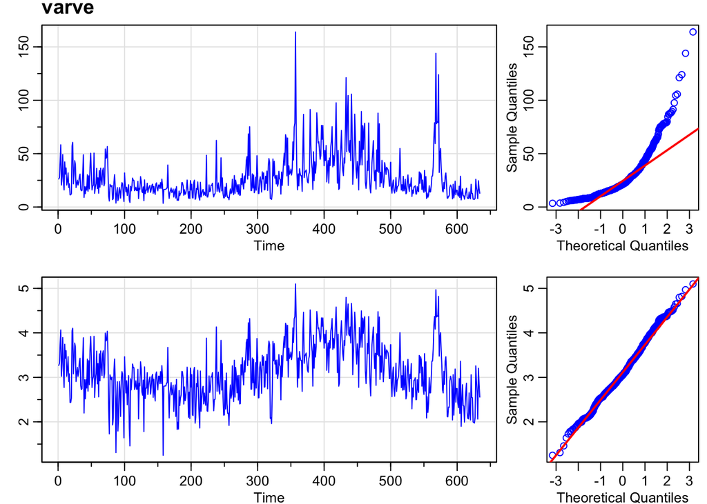

```r
layout(matrix(1:4,2), widths = c(2.5,1))
par(mgp = c(1.6,0.6,0), mar = c(2,2,0.5,0)+0.5)
tsplot(varve, main = "", ylab = "",col = 4, margin = 0)
mtext("varve", side = 3, line = 0.5, cex = 1.2, font = 2, adj = 0)
tsplot(log(varve), main = "", ylab = "", col = 4, margin = 0)
mtext("log(varve)", side = 3, line = 0.5, cex = 1.2, font = 2, adj = 9)

qqnorm(varve, main = "", col = 4); qqline(varve, col = 2, lwd = 2)
qqnorm(log(varve), main = "", col = 4); qqline(log(varve), col = 2, lwd = 2)
```

with the help of these plots we can confirm that the approximation to normality is improved by transforming the data.

2. Plot the series 𝑌𝑡. Do any time intervals, of the order 100 years, exist where one can observe behavior comparable to that observed in the global temperature records in Figure 1.2 (page 3 of the textbook)?

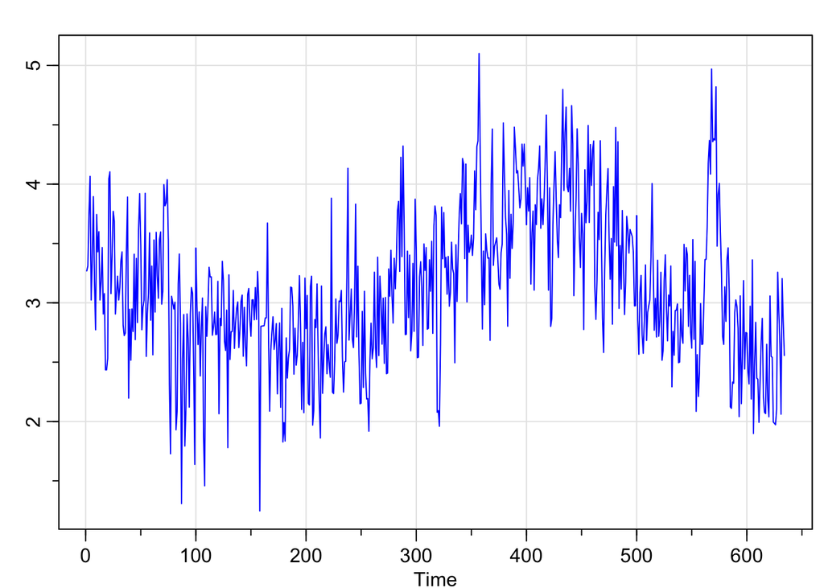

```r
#layout(matrix(1:2,2), widths = c(2.5,1))
tsplot(log(varve), main = "", ylab = "", col = 4, margin = 0)
mtext("log(varve)", side = 3, line = 0.5, cex = 1.2, font = 2, adj = 9)
```

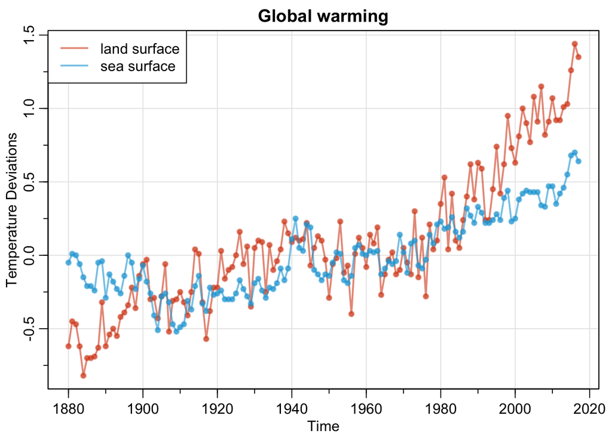

```r
culer = c(rgb(.85,.30,.12,.6), rgb(.12,.65,.85,.6))
tsplot(gtemp_land, col = culer[1], lwd = 2, type = "o", pch = 20, ylab = "Temperature Deviations", main = "Global warming")
lines(gtemp_ocean, col = culer[2], lwd = 2, type = "o", pch = 20)
legend("topleft", col = culer, lty = 1, lwd = 2, legend = c("land surface", "sea surface"), bg = "white")
```

In the plot with the log transformation of the data we can see that the time intervals [200:300] and [300:400] show an increase that resembles the general upward trend of the observed behavior in global temperature records.

3. Examine the sample ACF of 𝑌𝑡 and comment.

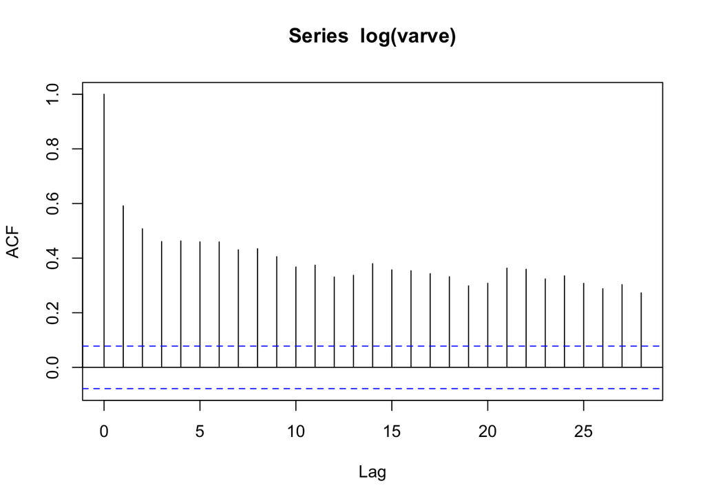

```r
acf(log(varve))
```

From the ACF plot we can observe non-stationary behavior since the values go well above the interval. Thus the log transformation helps stebalize the series but there is still more that could be done.

4. Compute the difference 𝑈𝑡=𝑌𝑡−𝑌𝑡−1, examine its time plot and sample ACF, and argue that differencing the logged varve data produces a reasonably stationary series.

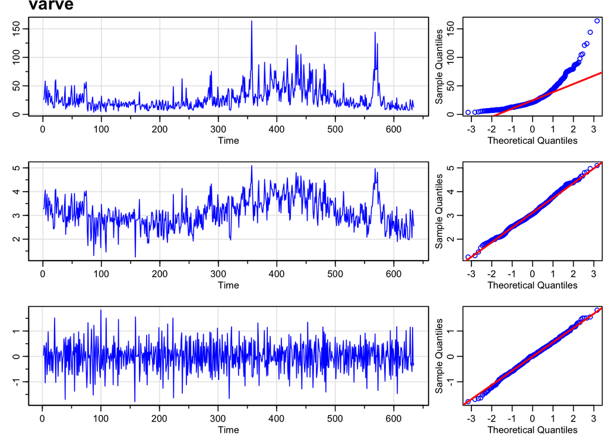

```r
layout(matrix(1:6,3), widths = c(2.5,1))
par(mgp = c(1.6,0.6,0), mar = c(2,2,0.5,0)+0.5)
tsplot(varve, main = "", ylab = "",col = 4, margin = 0)
mtext("varve", side = 3, line = 0.5, cex = 1.2, font = 2, adj = 0)
tsplot(log(varve), main = "", ylab = "", col = 4, margin = 0)
mtext("log(varve)", side = 3, line = 0.5, cex = 1.2, font = 2, adj = 9)
tsplot(diff(log(varve)), main = "", ylab = "", col = 4, margin = 0)
mtext("Diff(log(varve))", side = 3, line = 0.5, cex = 1.2, font = 2, adj = 9)
qqnorm(varve, main = "", col = 4); qqline(varve, col = 2, lwd = 2)
qqnorm(log(varve), main = "", col = 4); qqline(log(varve), col = 2, lwd = 2)
qqnorm(diff(log(varve)), main = "", col = 4); qqline(diff(log(varve)), col = 2, lwd = 2)
```

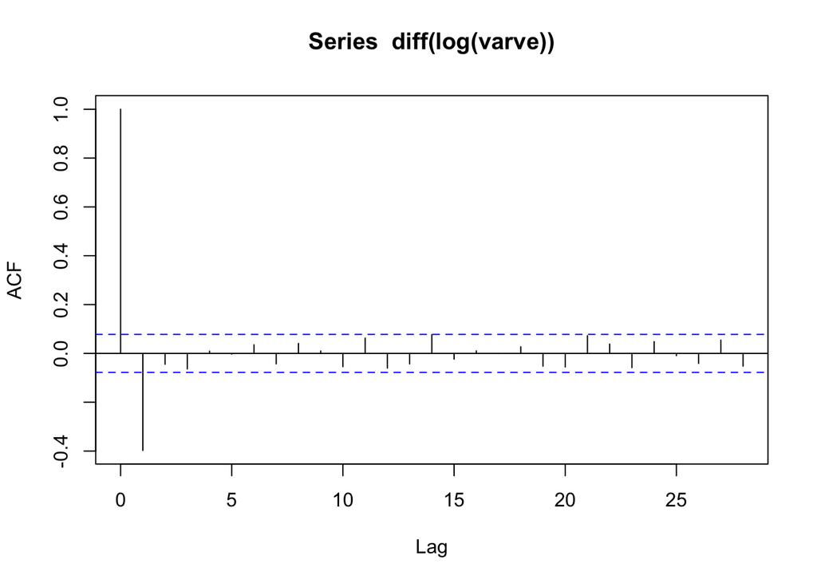

```r
acf(diff(log(varve)))
```

The third plot contains the difference of the log of the varves data. It can already bee seen a more uniform behavior throughout in the time series plot as well as in the qq plot. In addition the ACF for the difference is shown above and it shows that the difference produces a reasonably stationary series.